# Bootstrapping Diabetes Data to Illuminate Factors

Jorie Alvis, McKenna Hogan, and Cadeon Ott

# Introduction

Given the freedom in the requirements for this project, our team decided to tackle each bootstrapping method we learned in class to gain insights into a single dataset and learn more about each bootstrapping method. This class had shown us how to use these methods, when to use these methods, and the pros and cons of each method. Some differences between the methods are subtle (like basic and percentile), and some methods have major drawbacks (like BCa and Bootstrap `t`). In this paper, we will go over each method, some implemented by hand, and compare them against each other and to a skewed dataset.

The algorithms Standard Normal, Studentized, and BCa were coded by hand, and during the many hour process, we learned the nuances of these algorithms and the effort it takes to mitigate errors. Our team used this project to not only showcase the knowledge gained from this class, but to also expand our experience with these algorithms.

# Dataset

## Overview

The dataset consisted of health indicators for people with no diabetes, prediabetes, and diabetes.We chose to focus on the variables HighBP, HighChol, BMI, AnyHealthcare, GenHlth, and Income out of the 21 factors in the dataset

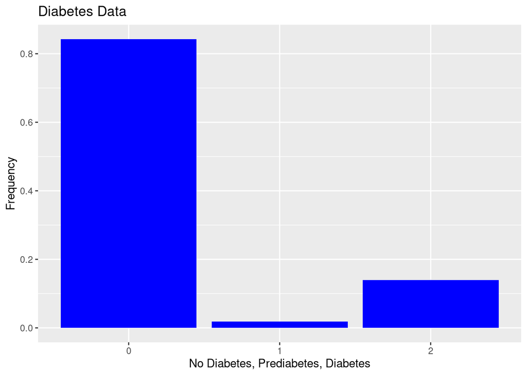

This graph showcases the differences in the number of observations between classifications. To analyze important factors that could indicate diabetes, we wanted to compare the distributions of each factors within the classes, but with this disparity, we thought bootstrapping would mitigate any issues that arise from the dramatic difference.

## Exploration

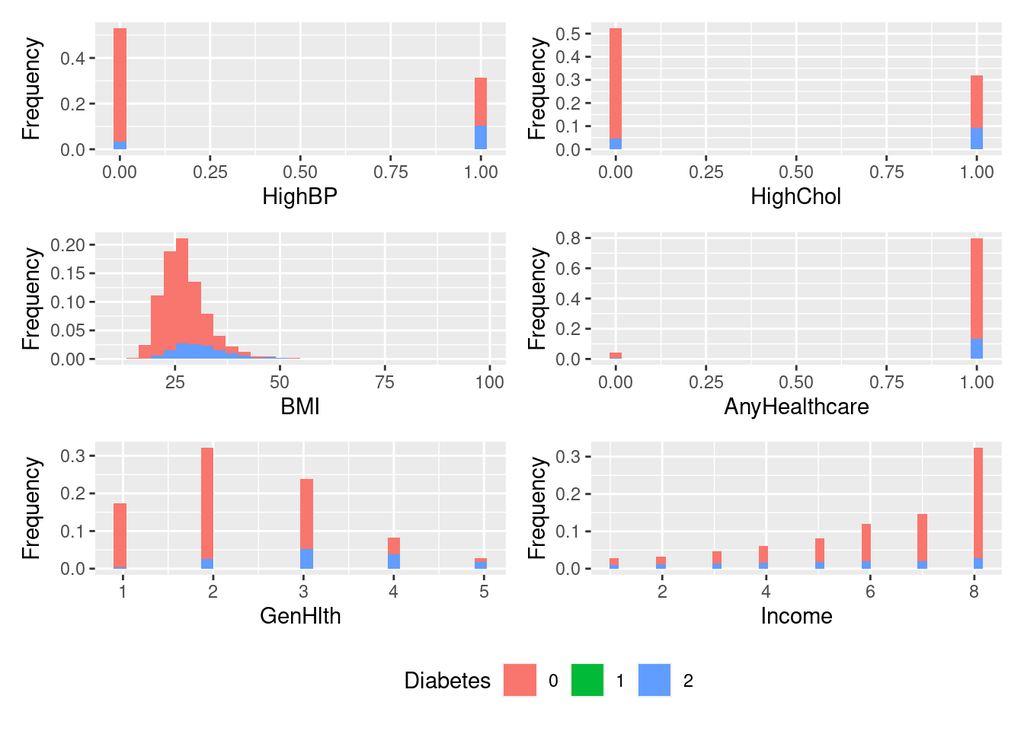

At a quick glance, we can see that there may be some difference between the classes, but with the frequency disparity (pre-diabetes doesn’t even show), we cannot come to any conclusions.

# Methods

We decided to bootstrap our data because there was a massive difference in sample sizes for the 3 classifications of patients. We utilized all 5 types of bootstrapping.

## Percentile and Basic

In my results, I found that there was a significant difference in means for most of my combinations. The only variable that didn’t have consistent significant difference in means was the AnyHealthcare variable. I also found that the percentile and basic bootstraps were very similar which matched both my assumption and my findings for 0 SE.

The following are tables showing the difference in means among the combinations of no diabetes, prediabetes, and diabetes for all the variables and for both kinds of bootstrapping:

No Diabetes - Prediabetes

|  | mean | low percentile | high percentile | low basic | high basic |
| --- | --- | --- | --- | --- | --- |
| HighBP | -0.258 | -0.272 | -0.244 | -0.272 | -0.243 |
| HighChol | -0.241 | -0.255 | -0.227 | -0.257 | -0.228 |
| BMI | -2.984 | -3.173 | -2.783 | -3.181 | -2.791 |
| AnyHealthcare | 0.005 | -0.002 | 0.011 | -0.002 | 0.011 |
| GenHlth | -0.603 | -0.632 | -0.572 | -0.635 | -0.575 |
| Income | 0.857 | 0.790 | 0.920 | 0.795 | 0.925 |

Prediabetes - Diabetes

[output not shown]

Diabetes - No Diabetes

[output not shown]

The following are the histograms for each combination of difference in means for:

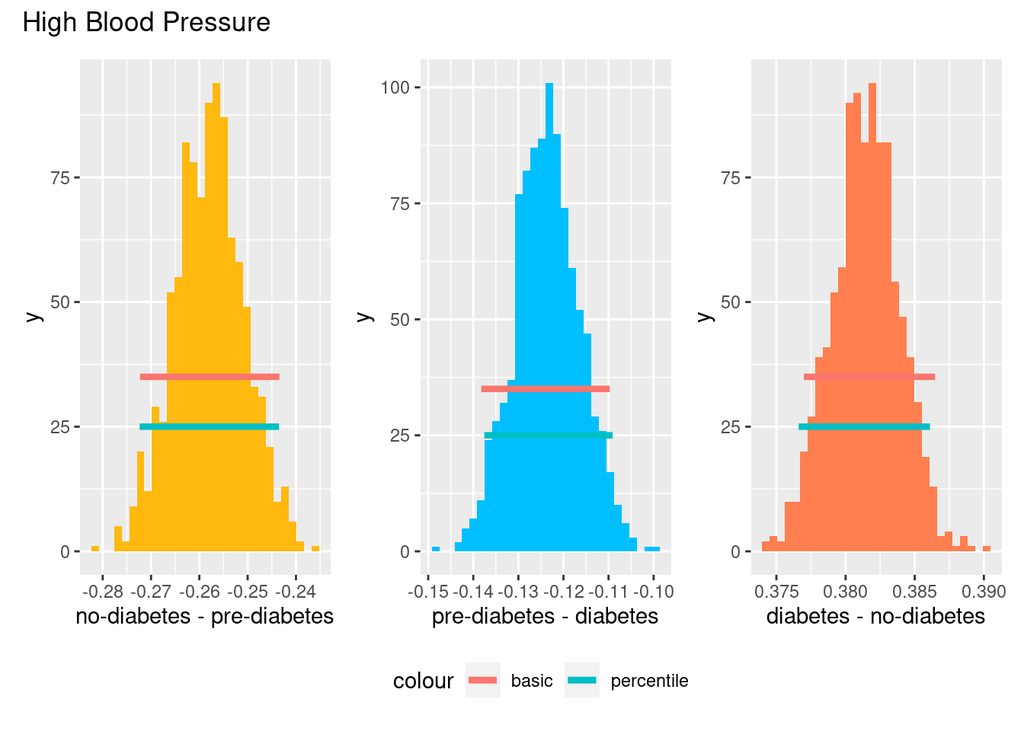

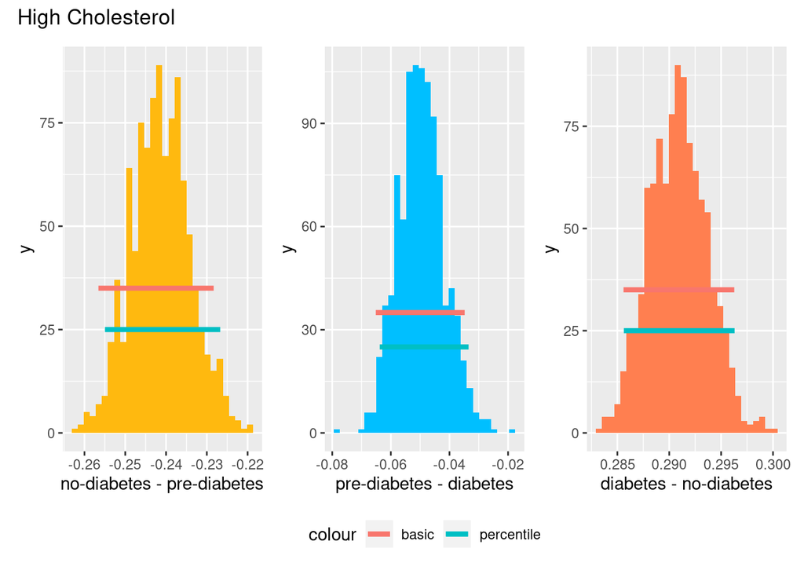

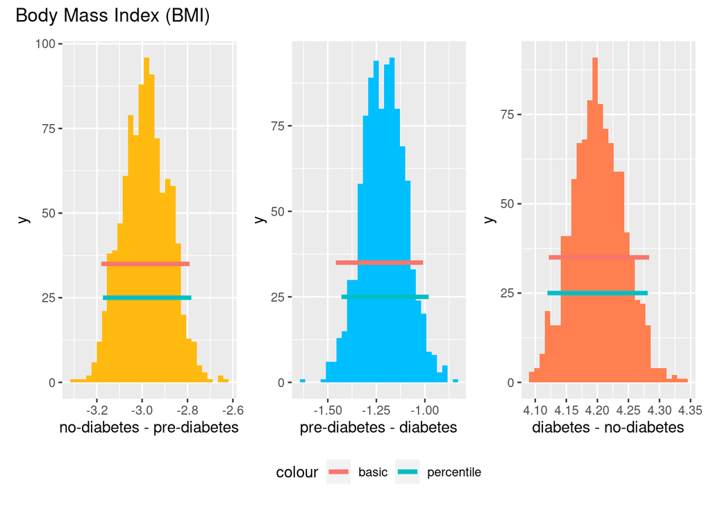

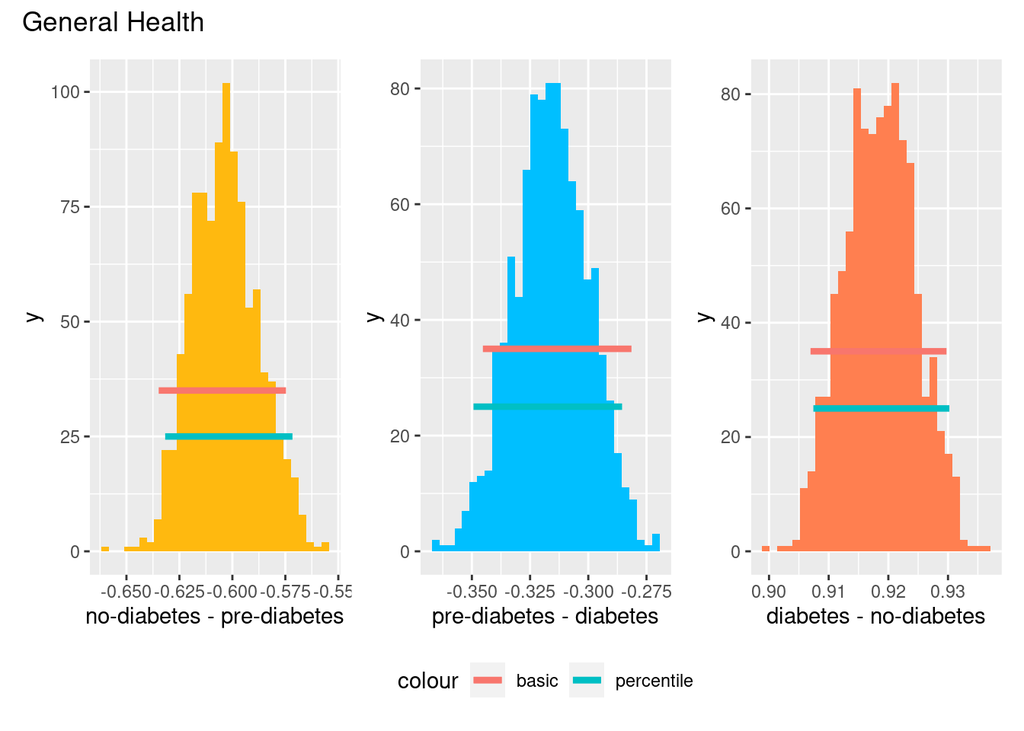

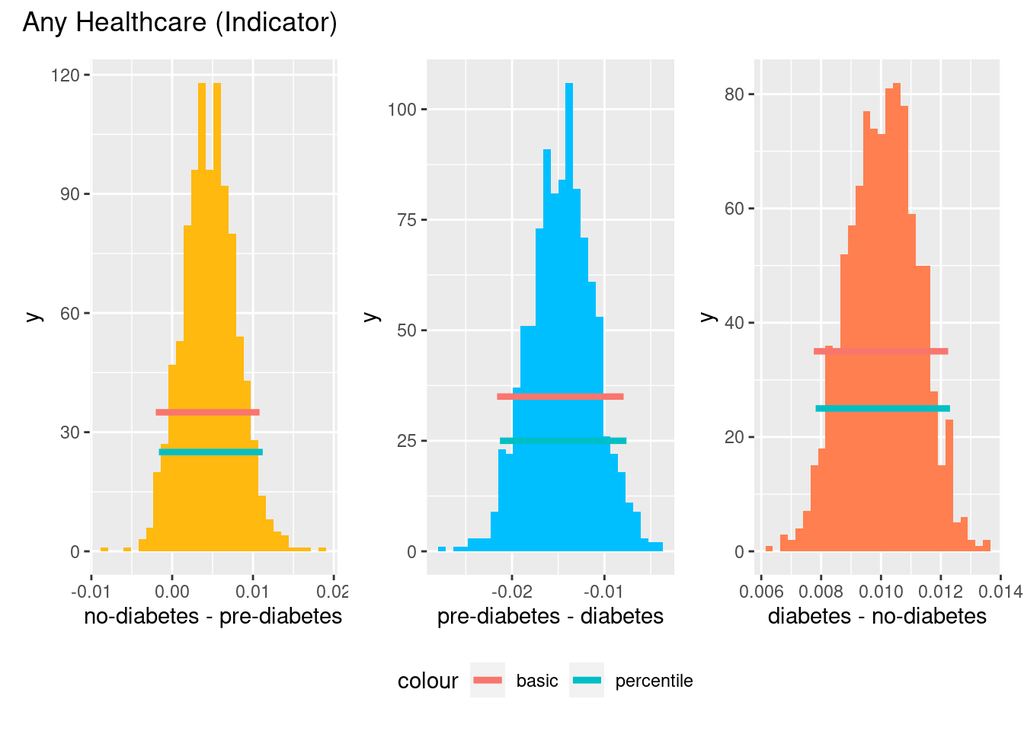

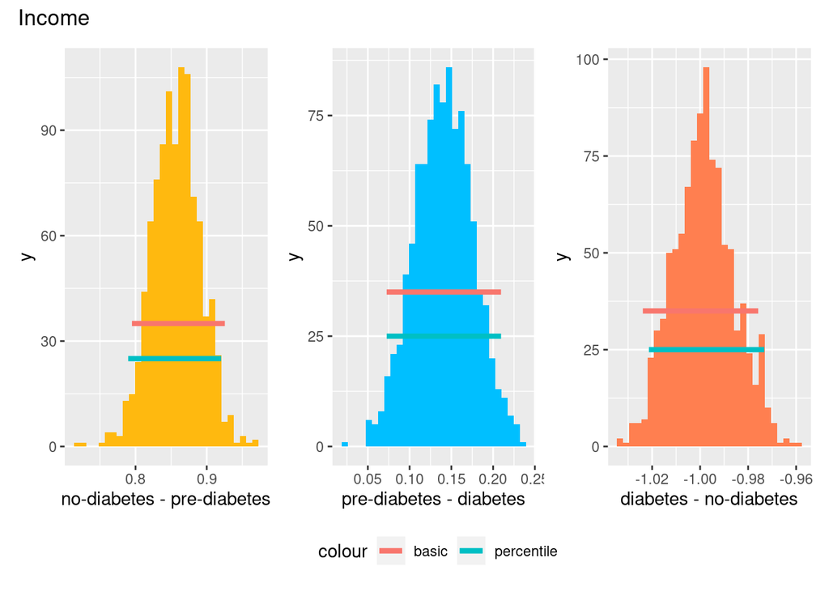

As you can see from these histograms, 0 is almost never included in the interval. The only times 0 is in the interval is for AnyHealthcare. This means that the difference in means between no no diabetes and pre-diabetes, pre-diabetes and diabetes, and diabetes and no diabetes are significant for every variable but AnyHealthcare. The fact that the basic and percentile CI’s are extremely similar show that there is no bias in the samples. This matched the outputted values for SE.

### Results

For the percentile and basic bootstrapping, I decided to focus on the difference in means and seeing if there was any difference between the two types of bootstrapping to check my assumptions bout biasness. If there was a large difference between my methods, that would have meant there was bias in the sample. My calculations showed no bias so I wanted to make sure that my bootstrapping methods matched this finding. I used R=1000 for each bootstrap and found the difference in means for each variable for the 3 combinations of no diabetes, prediabetes, and diabetes.

## Normal and Studentized

### Bootstrap Sampleing

The code bellow shows the algorithm we used to sample from the data

```r
bootSample = function(data, m, n) {
  ret = list()
  for (i in 1:m) {
    # Sample of size n for No Diabetes
    sample.no_d = sample(1:length(data[data$Diabetes == 0,]), size=n, replace=TRUE)
    data.sample.no_d = data[data$Diabetes == 0,][sample.no_d,]

    # Sample of size n for Pre-Diabetes
    sample.pre_d = sample(1:length(data[data$Diabetes == 1,]), size=n, replace=TRUE)
    data.sample.pre_d = data[data$Diabetes == 1,][sample.pre_d,]

    # Sample of size n for Diabetes
    sample.d = sample(1:length(data[data$Diabetes == 2,]), size=n, replace=TRUE)
    data.sample.d = data[data$Diabetes == 2,][sample.d,]

    # Row bind the three samples
    data.sample = rbind(data.sample.no_d, data.sample.pre_d, data.sample.d)

    ret[[i]] = data.sample
  }

  return(ret)
}
```

### Standard Normal Bootstrap CI Code

The Standard Normal Bootstrap CI uses the mean of each sample to estimate a standard error for $\hat{\theta}$ and creates a confidence interval using the Standard Normal Distribution around it.

$S_1,S_2,...,S_m\sim\text{Data}$

$\hat{\theta}_m=\text{mean}(S_m)$

$\hat{\theta}=\text{mean}(\hat{\theta}_1,\hat{\theta}_2,...)\text{ and }\hat{\text{se}}(\hat{\theta})=\text{sd}(\hat{\theta}_1,\hat{\theta}_2,...)$

The interval is $\hat{\theta}\pm z_{\alpha/2}\hat{\text{ se}}(\hat{\theta})$

```r
normal_boot = function(data_list, factors) {
  # The returned list sorted by:
  ## Name of Factor, Class of Diabetes, each sample in the bootstrap
  ret = list()

  # For each factor of interest
  for (col_name in factors) {
    # List of combined statistics for each class of diabetes and individual sample
    combo = list()

    # For each class of diabetes
    for (d in 0:2) {
      # The data frame of statistics for each sample
      data.stats = setNames(data.frame(matrix(ncol = 4, nrow = length(data_list))),
                            c("mean", "sd", "lower", "upper"))

      # For each sample
      for (i in 1:length(data_list)) {
        data.sample = data_list[[i]] %>% filter(Diabetes==d) %>% pull(col_name)

        data.mean = mean(data.sample)
        data.sd = sd(data.sample)

        delta = pnorm((1-0.95/2))*data.sd
        data.lower = data.mean-delta
        data.upper = data.mean+delta

        data.stats[i,] = c(data.mean, data.sd, data.lower, data.upper)
      }
      # Calculate the statistics across all the samples
      theta.hat = mean(data.stats$mean)
      theta.se = sd(data.stats$mean)

      delta = pnorm((1-0.95/2))*theta.se
      theta.lower = theta.hat-delta
      theta.upper = theta.hat+delta

      data.stats[length(data_list)+1,] = c(theta.hat, theta.se, theta.lower, theta.upper)

      combo[[d+1]] = data.stats
    }
    ret[[col_name]] = combo
  }
  return(ret)
}
```

### Studentized Bootstrap CI Code

The Studentized Bootstrap CI uses each bootstrap sample to find a $t$ statistic for that sample, then uses the $\alpha/2$ quantiles of the statistics to find the confidence interval.

$S_1,S_2,...,S_m\sim\text{Data}$

$\hat{\theta}_m=\text{mean}(S_m)$

$R_1^m,R_2^m,...,R_m^m\sim\text{S_m}$

$\hat{\theta}^{(m)}_m=\text{mean}(R_m^m)$

$\hat{\theta}^{(m)}=\text{mean}(R_1^m,R_2^m,...,R_m^m)\text{ and }\hat{\text{se}}(\hat{\theta}^{(m)})=\text{sd}(\hat{\theta}^{(m)}_1,\hat{\theta}^{(m)}_2,...)$

$t_m=\frac{\hat{\theta}^{(m)}-\hat{\theta}}{\hat{\text{se}}(\hat{\theta}^{(m)})}$

$\hat{\theta}=\text{mean}(\hat{\theta}_1,\hat{\theta}_2,...)\text{ and }\hat{\text{se}}(\hat{\theta})=\text{sd}(\hat{\theta}_1,\hat{\theta}_2,...)$

The interval is $\hat{\theta}\pm t_{\alpha/2}\hat{\text{ se}}(\hat{\theta})$ where $t_{\alpha/2}$ comes from the upper on lower quantile of $t_m$.

### Pairs of `m` and `n` values

#### Tables of standard error of our estimators for Standard Normal CI

Income and No Diabetes

|  | n=10 | n=25 | n=75 | n=125 | n=250 |
| --- | --- | --- | --- | --- | --- |
| m=10 | 0.808 | 0.486 | 0.247 | 0.205 | 0.108 |
| m=30 | 0.827 | 0.422 | 0.241 | 0.185 | 0.164 |
| m=50 | 0.701 | 0.506 | 0.293 | 0.233 | 0.119 |
| m=100 | 0.769 | 0.457 | 0.246 | 0.215 | 0.153 |
| m=250 | 0.828 | 0.506 | 0.280 | 0.217 | 0.140 |

Income and Pre-Diabetes

|  | n=10 | n=25 | n=75 | n=125 | n=250 |
| --- | --- | --- | --- | --- | --- |
| m=10 | 0.908 | 0.302 | 0.205 | 0.190 | 0.095 |
| m=30 | 0.600 | 0.326 | 0.191 | 0.167 | 0.137 |
| m=50 | 0.654 | 0.411 | 0.211 | 0.181 | 0.133 |
| m=100 | 0.612 | 0.390 | 0.231 | 0.175 | 0.106 |
| m=250 | 0.618 | 0.372 | 0.228 | 0.174 | 0.123 |

Income and Diabetes

|  | n=10 | n=25 | n=75 | n=125 | n=250 |
| --- | --- | --- | --- | --- | --- |
| m=10 | 0.576 | 0.306 | 0.169 | 0.159 | 0.159 |
| m=30 | 0.636 | 0.485 | 0.293 | 0.164 | 0.126 |
| m=50 | 0.671 | 0.405 | 0.235 | 0.164 | 0.135 |
| m=100 | 0.707 | 0.459 | 0.252 | 0.196 | 0.147 |
| m=250 | 0.692 | 0.430 | 0.259 | 0.175 | 0.143 |

AnyHealthcare and No Diabetes

|  | n=10 | n=25 | n=75 | n=125 | n=250 |
| --- | --- | --- | --- | --- | --- |
| m=10 | 0.070 | 0.060 | 0.023 | 0.027 | 0.013 |
| m=30 | 0.077 | 0.041 | 0.023 | 0.022 | 0.013 |
| m=50 | 0.070 | 0.044 | 0.028 | 0.020 | 0.013 |
| m=100 | 0.069 | 0.036 | 0.023 | 0.018 | 0.013 |
| m=250 | 0.066 | 0.038 | 0.023 | 0.018 | 0.012 |

AnyHealthcare and Pre-Diabetes

|  | n=10 | n=25 | n=75 | n=125 | n=250 |
| --- | --- | --- | --- | --- | --- |
| m=10 | 0.048 | 0.076 | 0.016 | 0.025 | 0.009 |
| m=30 | 0.061 | 0.041 | 0.022 | 0.020 | 0.015 |
| m=50 | 0.061 | 0.042 | 0.026 | 0.020 | 0.014 |
| m=100 | 0.070 | 0.043 | 0.025 | 0.020 | 0.015 |
| m=250 | 0.065 | 0.043 | 0.023 | 0.018 | 0.013 |

AnyHealthcare and Diabetes

|  | n=10 | n=25 | n=75 | n=125 | n=250 |
| --- | --- | --- | --- | --- | --- |
| m=10 | 0 | 0 | 0 | 0 | 0 |
| m=30 | 0 | 0 | 0 | 0 | 0 |
| m=50 | 0 | 0 | 0 | 0 | 0 |
| m=100 | 0 | 0 | 0 | 0 | 0 |
| m=250 | 0 | 0 | 0 | 0 | 0 |

#### Tables of standard error of our estimators for Studentized CI

Income and No Diabetes

|  | n=10 | n=25 | n=75 | n=125 | n=250 |
| --- | --- | --- | --- | --- | --- |
| m=10 | 0.708 | 0.429 | 0.203 | 0.227 | 0.201 |
| m=30 | 0.713 | 0.447 | 0.234 | 0.209 | 0.148 |
| m=50 | 0.849 | 0.510 | 0.274 | 0.211 | 0.164 |
| m=100 | 0.701 | 0.456 | 0.270 | 0.215 | 0.156 |
| m=250 | 0.774 | 0.490 | 0.268 | 0.227 | 0.148 |

Income and Pre-Diabetes

|  | n=10 | n=25 | n=75 | n=125 | n=250 |
| --- | --- | --- | --- | --- | --- |
| m=10 | 0.331 | 0.249 | 0.188 | 0.245 | 0.100 |
| m=30 | 0.705 | 0.364 | 0.194 | 0.191 | 0.098 |
| m=50 | 0.533 | 0.376 | 0.239 | 0.181 | 0.147 |
| m=100 | 0.601 | 0.341 | 0.217 | 0.181 | 0.113 |
| m=250 | 0.639 | 0.414 | 0.208 | 0.163 | 0.119 |

Income and Diabetes

|  | n=10 | n=25 | n=75 | n=125 | n=250 |
| --- | --- | --- | --- | --- | --- |
| m=10 | 0.985 | 0.443 | 0.315 | 0.147 | 0.149 |
| m=30 | 0.735 | 0.434 | 0.276 | 0.221 | 0.120 |
| m=50 | 0.702 | 0.492 | 0.248 | 0.165 | 0.142 |
| m=100 | 0.747 | 0.419 | 0.269 | 0.199 | 0.142 |
| m=250 | 0.708 | 0.406 | 0.237 | 0.196 | 0.131 |

AnyHealthcare and No Diabetes

|  | n=10 | n=25 | n=75 | n=125 | n=250 |
| --- | --- | --- | --- | --- | --- |
| m=10 | 0.052 | 0.053 | 0.011 | 0.013 | 0.012 |
| m=30 | 0.073 | 0.045 | 0.026 | 0.016 | 0.013 |
| m=50 | 0.057 | 0.045 | 0.028 | 0.020 | 0.012 |
| m=100 | 0.051 | 0.048 | 0.021 | 0.018 | 0.015 |
| m=250 | 0.060 | 0.043 | 0.024 | 0.018 | 0.013 |

AnyHealthcare and Pre-Diabetes

|  | n=10 | n=25 | n=75 | n=125 | n=250 |
| --- | --- | --- | --- | --- | --- |
| m=10 | 0.071 | 0.039 | 0.028 | 0.016 | 0.014 |
| m=30 | 0.066 | 0.034 | 0.024 | 0.023 | 0.013 |
| m=50 | 0.059 | 0.037 | 0.026 | 0.016 | 0.014 |
| m=100 | 0.063 | 0.037 | 0.024 | 0.016 | 0.011 |
| m=250 | 0.065 | 0.040 | 0.024 | 0.020 | 0.013 |

AnyHealthcare and Diabetes

|  | n=10 | n=25 | n=75 | n=125 | n=250 |
| --- | --- | --- | --- | --- | --- |
| m=10 | 0 | 0 | 0 | 0 | 0 |
| m=30 | 0 | 0 | 0 | 0 | 0 |
| m=50 | 0 | 0 | 0 | 0 | 0 |
| m=100 | 0 | 0 | 0 | 0 | 0 |
| m=250 | 0 | 0 | 0 | 0 | 0 |

### Income

Normal CI on Income

|  | mean | lower | upper |
| --- | --- | --- | --- |
| No Diabetes | 5.186 | 5.088 | 5.284 |
| Pre-Diabetes | 4.938 | 4.852 | 5.024 |
| Diabetes | 4.862 | 4.762 | 4.963 |

Student-t CI on Income

|  | mean | lower | upper |
| --- | --- | --- | --- |
| No Diabetes | 5.197 | 3.914 | 5.901 |
| Pre-Diabetes | 4.960 | 4.328 | 5.113 |
| Diabetes | 4.862 | 4.300 | 4.945 |

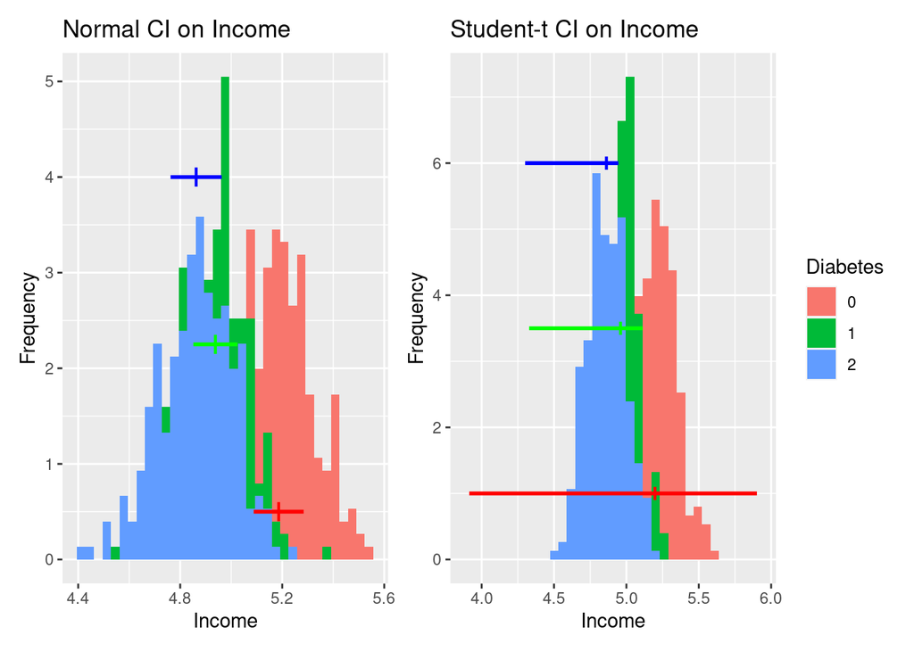

### BMI

Normal CI on BMI

|  | mean | lower | upper |
| --- | --- | --- | --- |
| No Diabetes | 28.423 | 28.198 | 28.649 |
| Pre-Diabetes | 32.912 | 32.668 | 33.157 |
| Diabetes | 29.233 | 28.992 | 29.474 |

Student-t CI on BMI

|  | mean | lower | upper |
| --- | --- | --- | --- |
| No Diabetes | 28.401 | 28.249 | 29.663 |
| Pre-Diabetes | 32.920 | 31.311 | 35.740 |
| Diabetes | 29.288 | 25.447 | 31.188 |

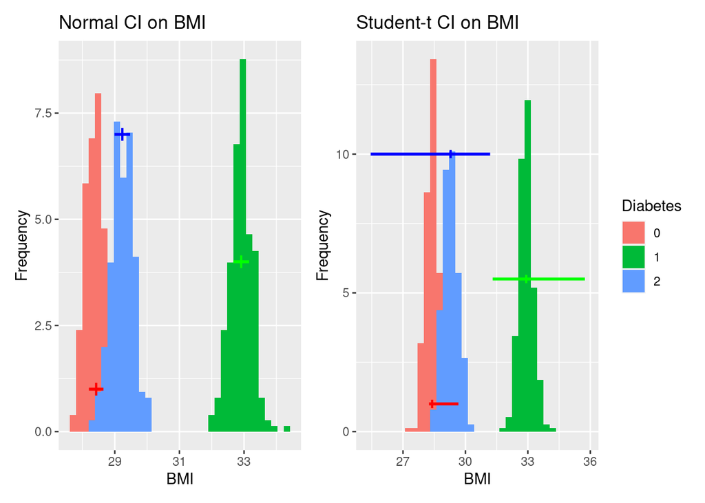

### GenHlth

Normal CI on GenHlth

|  | mean | lower | upper |
| --- | --- | --- | --- |
| No Diabetes | 2.860 | 2.810 | 2.909 |
| Pre-Diabetes | 3.590 | 3.537 | 3.642 |
| Diabetes | 3.055 | 3.004 | 3.105 |

Student-t CI on GenHlth

|  | mean | lower | upper |
| --- | --- | --- | --- |
| No Diabetes | 2.860 | 2.490 | 3.451 |
| Pre-Diabetes | 3.589 | 3.123 | 4.403 |
| Diabetes | 3.055 | 2.615 | 3.128 |

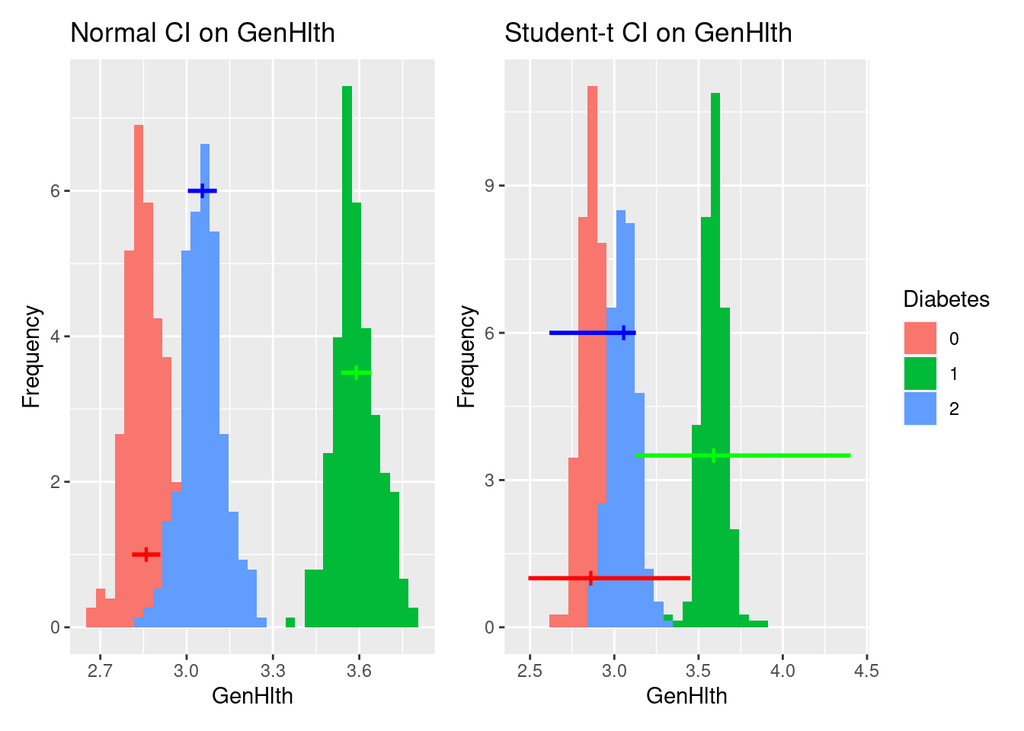

### HighBP

Normal CI on HighBP

|  | mean | lower | upper |
| --- | --- | --- | --- |
| No Diabetes | 0.588 | 0.565 | 0.610 |
| Pre-Diabetes | 0.638 | 0.617 | 0.659 |
| Diabetes | 0.866 | 0.853 | 0.879 |

Student-t CI on HighBP

|  | mean | lower | upper |
| --- | --- | --- | --- |
| No Diabetes | 0.590 | 0.429 | 0.873 |
| Pre-Diabetes | 0.635 | 0.579 | 0.711 |
| Diabetes | 0.864 | 0.799 | 1.064 |

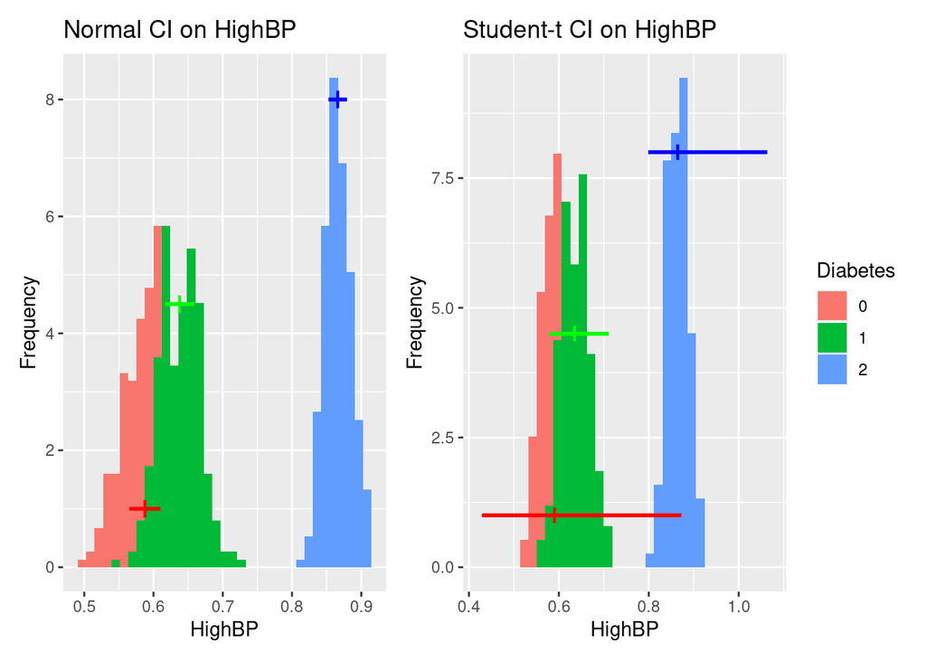

### AnyHealthcare

Normal CI on AnyHealthcare

|  | mean | lower | upper |
| --- | --- | --- | --- |
| No Diabetes | 0.955 | 0.946 | 0.963 |
| Pre-Diabetes | 0.953 | 0.944 | 0.962 |
| Diabetes | 1.000 | 1.000 | 1.000 |

Student-t CI on AnyHealthcare

|  | mean | lower | upper |
| --- | --- | --- | --- |
| No Diabetes | 0.956 | 0.938 | 0.992 |
| Pre-Diabetes | 0.954 | 0.938 | 0.999 |
| Diabetes | 1.000 | NaN | NaN |

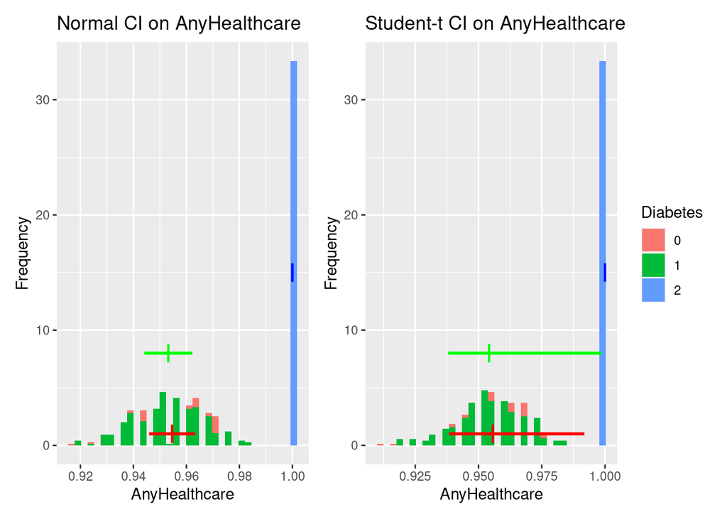

### Normal and Studentized Conclusion

From all of these graphs, we can see that the Standard Normal out-preforms the Studentized interval for every factor. I think the size of the Studentized interval can be decreased if we increase the number of samples, but as we went over in class, the distribution of the t-style statistics can be quite extreme. If I had more time, I would explore the distributions of the t-style statistics across different number of samples and sample size (for both levels of bootstrapping).

## BCa

To start out my analysis, I had to figure out how I was going to sample from such a massive data set. I used the following function to sample from a selected indicator with parameters `m` and `n`:

```r
f1 <- function(data, m,n){

  bootstrap_data <- list()
  for(i in 1:m){
    temp_sample_ind <- sample(1:length(data), n,replace=TRUE)
    bootstrap_data[[i]] <- data[temp_sample_ind]
  }
  return(bootstrap_data)
}
```

I used the equation:

$g(u) = \hat{F}^{-1}(\phi(z_0 + \frac{z_0 + z_u}{1-a(z_0+z_u)}))$

Lower bound = $g(\alpha/2)$, Upper bound = $g(1-\alpha/2)$ $\phi$ is the standard normal cdf $\hat{F}$ is the bootstrap cdf $z_0 = \phi^{-1}F(\hat{\theta})$, quantile of mean of theta_boot <= theta_hat $z_u = \phi^{-1}(u)$, quantiles of our desired bounds

$\hat{a} = \frac{1}{6}\frac{\sum_{i=1}^n I_i^3}{(\sum_{i=1}^n I_i^2)^{3/2}}$

$I_i = (n-1)(\hat{\theta}-\hat{\theta}_{-i})$ finite sample jacknife approx.

I implemented $g(u)$ with this code:

```r
bca_CI <- function(theta_boot,theta_hat,m){

  alpha <- 0.05
  u <- c(alpha/2, 1-alpha/2)
  z0 <- qnorm(mean(theta_boot <= theta_hat))
  zu <- qnorm(u)
  a <- 0
  #because the sample size of our data set is so large, the computation
  #is too intensive for rstudio to conduct. With such a large data set a should
  #be close to zero anyways, so I elected to choose zero.

  u_adjusted <- pnorm(z0 + (z0+zu)/(1-a*(z0+zu)))
  #u_adjusted <- pnorm(z0 + (z0+zu)/(1-a_approx*(z0+zu)))
  conf_int <- quantile(theta_boot,u_adjusted)
  return(conf_int)

}
```

Originally, I did not have `a` set to zero. I used this function to approximate `a`:

```r
a_est <- function(data,theta_hat){
  n <- length(data)
  I <- rep(NA, n)
for(i in 1:n){
   #Remove ith data point
   xnew <- data[-i]
   #Estimate theta
   theta_jack <- mean(xnew)
   I[i] <- (n-1)*(theta_hat - theta_jack)
}
#Estimate a
  a_hat <- (sum(I^3)/sum(I^2)^1.5)/6
  return(a_hat)
}
```

Now I was ready to perform BCa confidence intervals! I threw in the data of my selected indicator, and clicked run.

Here is where I started running into problems. My computer ran for about 10 minutes before I eventually halted the program. Why was this taking so long?

To first check and see if I was doing something wrong, I used the boot.ci package to compute a BCa confidence interval. However, this also would run and begin taxing the memory allocation. I checked the other confidence intervals and noticed that they would compute almost immediately. There was something about the BCa computation that was computationally intensive.

After staring at my code and equation for two days, I finally made a breakthrough. `a` has to iterate through every single observation, take (n-1) * (mean of the dataset - mean of the dataset with one less observation), and plug it into $I_n$. I realized that this computation was happening 253,680 times (the length of the number of observations per column in our data set). This was a massive calculation. I read more into what the acceleration constant actually meant, and realized that it was adjusting for skew using the infinitesimal jackknife method, which reasonably approximates `a` with smaller sample sizes. With a very high `n`, the central limit theorem kicks in, and each indicator is approximately normally distributed. Thus, with a normal distribution, the skew approaches zero as `n` -> infinity. Therefore, I made the choice to set `a` as zero, which effectively changes my Bias corrected and accelerated confidence intervals to Bias corrected confidence intervals.

With `a` now set to zero, I could start computing confidence intervals. I decided to create a master function that sampled from a selected indicator for no diabetes, pre diabetes, and diabetes, with a vector of all desired boot strap replications and sample sizes. I also had to include the overall mean for each indicator so it could be used in the BCa function call.

```r
bca_compile <- function(data0,data1,data2,theta_hat1,theta_hat2,theta_hat3,m,n){
  data.stats = setNames(data.frame(matrix(ncol = 12, nrow = length(m)*length(n))),
                 c("mean1", "sd1","ci_1_lower","ci_1_upper","mean2", "sd2","ci_2_lower","ci_2_upper","mean3", "sd3","ci_3_lower","ci_3_upper"))
  row.names(data.stats) <- c("m5,n10","m5,n25","m5,n75","m5,n125","m5,n250","m10,n10","m10,n25","m10,n75","m10,n125","m10,n250","m15,n10","m15,n25","m15,n75","m15,n125","m15,n250","m30,n10","m30,n25","m30,n75","m30,n125","m30,n250","m50,n10","m50,n25","m50,n75","m50,n125","m50,n250")
  counter=1
  bca_CI_means <- data.frame(matrix(ncol=3,nrow=m[5]))
  for(r in 1:length(m)){
    for(c in 1:length(n)){
      b0 <- f1(data0,m[r],n[c])
      b0_mean <- b_means(b0,m[r])
      b0_se <- b_sds(b0,m[r])

      b1 <- f1(data1,m[r],n[c])
      b1_mean <- b_means(b1,m[r])
      b1_se <- b_sds(b1,m[r])

      b2<- f1(data2,m[r],n[c])
      b2_mean <- b_means(b2,m[r])
      b2_se <- b_sds(b2,m[r])

      # b_mean_diff <- rep(NA,m[r])
      # b_se_diff <- rep(NA,m[r])
      # for(i in 1:m[r]){
      #   b_mean_diff[i] <- b0_mean[i]-b1_mean[i]
      #   b_se_diff[i] <- b0_se[i]-b1_se[i]
      # }
      # b_theta_hat_diff <- theta_hat1-theta_hat2
      #
      #
      #
      # b_ci_diff <- bca_CI(b_mean_diff,b_theta_hat_diff,m[r])
      b0_ci <- bca_CI(b0_mean,theta_hat1,m[r])
      b1_ci <- bca_CI(b1_mean,theta_hat2,m[r])
      b2_ci <- bca_CI(b2_mean,theta_hat3,m[r])

      data.stats[counter,] <- c(mean(b0_mean),mean(b0_se),b0_ci[1],b0_ci[2],mean(b1_mean),mean(b1_se),b1_ci[1],b1_ci[2],mean(b2_mean),mean(b2_se),b2_ci[1],b2_ci[2])
      counter <- counter + 1
      if(m[r] == 50 & n[c] == 250){
        bca_CI_means[,1] <- b0_mean
        bca_CI_means[,2] <- b1_mean
        bca_CI_means[,3] <- b2_mean

      }
    }
  }


  return(list(data.stats,bca_CI_means))

}
```

This function returns a list of two data frames. The first data frame is a master data frame which has the mean, standard error, and bounds for the BCa confidence interval for no diabetes, pre-diabetes, and diabetes of a selected indicator, for all `m` and `n`. The second data frame is a list of the means of each bootstrapped sample for `m` = 50 and `n` = 250, which I used to plot the histograms.

Now was time to plot my results and showcase the relationships. I started by creating master functions for each variable, as well as creating data frames with labels so that the data could be plotted and readable.

```r
m_vec <- c(5,10,15,30,50)
n_vec <- c(10,25,75,125,250)

nodibindic <- rep("No Diabetes",50)
predibindic <- rep("Pre Diabetes",50)
dibindic <- rep("Diabetes",50)
indic <- c(nodibindic,predibindic,dibindic)



a <- bca_compile(nodib$HighBP,predib$HighBP,dib$HighBP,mean(nodib$HighBP),mean(predib$HighBP),mean(dib$HighBP),m_vec,n_vec)
a1 <- a[[1]]
a2 <- a[[2]]
highBP <- c(a2[,1],a2[,2],a2[,3])
#a3 <- cbind(a3,indic)
a3 <- data.frame(highBP,group=indic)

b <- bca_compile(nodib$HighChol,predib$HighChol,dib$HighChol,mean(nodib$HighChol),mean(predib$HighChol),mean(dib$HighChol),m_vec,n_vec)
b1 <- b[[1]]
b2 <- b[[2]]
highChol <- c(b2[,1],b2[,2],b2[,3])
b3 <- data.frame(highChol,group = indic)

c <- bca_compile(nodib$BMI,predib$BMI,dib$BMI,mean(nodib$BMI),mean(predib$BMI),mean(dib$BMI),m_vec,n_vec)
c1 <- c[[1]]
c2 <- c[[2]]
BMI <- c(c2[,1],c2[,2],c2[,3])
c3 <- data.frame(BMI,group=indic)

d <- bca_compile(nodib$AnyHealthcare,predib$AnyHealthcare,dib$AnyHealthcare,mean(nodib$AnyHealthcare),mean(predib$AnyHealthcare),mean(dib$AnyHealthcare),m_vec,n_vec)
d1 <- d[[1]]
d2 <- d[[2]]
AnyHealthcare <- c(d2[,1],d2[,2],d2[,3])
d3 <- data.frame(AnyHealthcare,group=indic)

e <- bca_compile(nodib$GenHlth,predib$GenHlth,dib$GenHlth,mean(nodib$GenHlth),mean(predib$GenHlth),mean(dib$GenHlth),m_vec,n_vec)
e1 <- e[[1]]
e2 <- e[[2]]
GenHlth <- c(e2[,1],e2[,2],e2[,3])
e3 <- data.frame(GenHlth,group=indic)

f <- bca_compile(nodib$Income,predib$Income,dib$Income,mean(nodib$Income),mean(predib$Income),mean(dib$Income),m_vec,n_vec)
f1 <- f[[1]]
f2 <- f[[2]]
Income <- c(f2[,1],f2[,2],f2[,3])
f3 <- data.frame(Income,group=indic)
```

Next, I created a table function that would neatly display the mean, standard error, and the bounds for a selected bootstrap replication and sample size. I decided to compare the smallest and largest bootstrap samples to really showcase the power of boostrapping. The table functions I created are displayed below.

```r
make_table <- function(data){
  t = setNames(data.frame(matrix(ncol = 4, nrow = 3)), c("Mean", "SD","CI_Low","CI_High"))
  row.names(t) <- c("No Diabetes","Pre Diabetes","Diabetes")
  t[1,1] = data[25,1]
  t[2,1] = data[25,5]
  t[3,1] = data[25,9]

  t[1,2] = data[25,2]
  t[2,2] = data[25,6]
  t[3,2] = data[25,10]

  t[1,3] = data[25,3]
  t[2,3] = data[25,7]
  t[3,3] = data[25,11]

  t[1,4] = data[25,4]
  t[2,4] = data[25,8]
  t[3,4] = data[25,12]

  return(t)
}
make_table2 <- function(data){
  t = setNames(data.frame(matrix(ncol = 4, nrow = 3)), c("Mean", "SD","CI_Low","CI_High"))
  row.names(t) <- c("No Diabetes","Pre Diabetes","Diabetes")
  t[1,1] = data[1,1]
  t[2,1] = data[1,5]
  t[3,1] = data[1,9]

  t[1,2] = data[1,2]
  t[2,2] = data[1,6]
  t[3,2] = data[1,10]

  t[1,3] = data[1,3]
  t[2,3] = data[1,7]
  t[3,3] = data[1,11]

  t[1,4] = data[1,4]
  t[2,4] = data[1,8]
  t[3,4] = data[1,12]

  return(t)
}
```

Now, it’s time to show off the statistical analysis! I formatted each slide to display the two tables and a histogram of the bootstrapped means. Over the top of each histogram is the BCa confidence interval for `m` = 50 and `n` = 250, and directly below it the BCa confidence interval for `m` = 5 and `n` = 10. With the confidence intervals over the plots, it is easy to distinguish the statistical significances.

## BCa High Blood Pressure

High Blood Pressure m=50 n=250

|  | Mean | SD | CI_Low | CI_High |
| --- | --- | --- | --- | --- |
| No Diabetes | 0.371 | 0.483 | 0.320 | 0.430 |
| Pre Diabetes | 0.638 | 0.480 | 0.532 | 0.700 |
| Diabetes | 0.761 | 0.426 | 0.693 | 0.798 |

High Blood Pressure m=5 n=10

|  | Mean | SD | CI_Low | CI_High |
| --- | --- | --- | --- | --- |
| No Diabetes | 0.38 | 0.500 | 0.2 | 0.400 |
| Pre Diabetes | 0.66 | 0.491 | 0.6 | 0.797 |
| Diabetes | 0.74 | 0.438 | 0.6 | 0.871 |

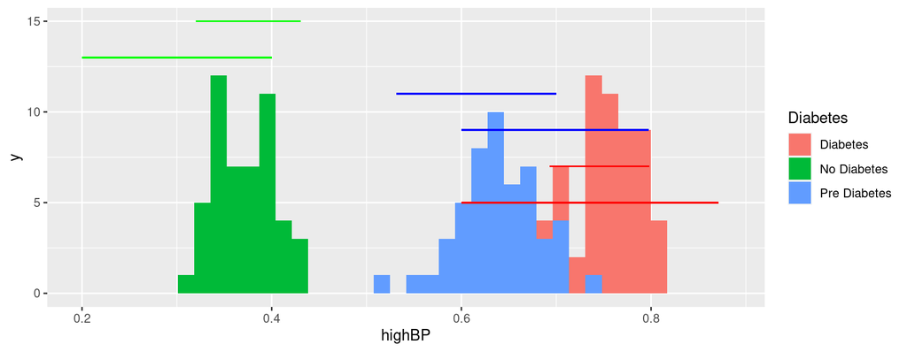

## BCa High Cholesterol

High Cholesterol m=50 n=250

|  | Mean | SD | CI_Low | CI_High |
| --- | --- | --- | --- | --- |
| No Diabetes | 0.378 | 0.485 | 0.310 | 0.436 |
| Pre Diabetes | 0.626 | 0.484 | 0.558 | 0.668 |
| Diabetes | 0.671 | 0.470 | 0.620 | 0.705 |

High Cholesterol m=5 n=10

|  | Mean | SD | CI_Low | CI_High |
| --- | --- | --- | --- | --- |
| No Diabetes | 0.44 | 0.512 | 0.300 | 0.444 |
| Pre Diabetes | 0.64 | 0.503 | 0.600 | 0.700 |
| Diabetes | 0.56 | 0.512 | 0.556 | 0.700 |

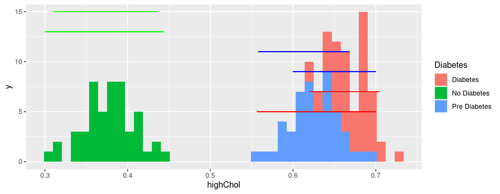

## BCa BMI

BMI m=50 n=250

|  | Mean | SD | CI_Low | CI_High |
| --- | --- | --- | --- | --- |
| No Diabetes | 27.670 | 6.096 | 27.141 | 28.568 |
| Pre Diabetes | 30.754 | 6.848 | 29.911 | 31.514 |
| Diabetes | 32.007 | 7.413 | 31.105 | 32.712 |

BMI m=5 n=10

|  | Mean | SD | CI_Low | CI_High |
| --- | --- | --- | --- | --- |
| No Diabetes | 28.98 | 5.76 | 26.716 | 30.737 |
| Pre Diabetes | 31.14 | 7.82 | 29.430 | 32.042 |
| Diabetes | 31.24 | 7.65 | 30.895 | 32.500 |

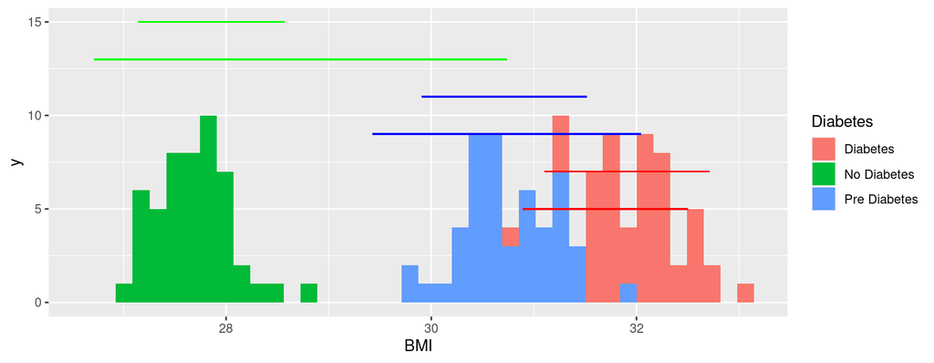

## BCa Any Healthcare

Any Healthcare m=50 n=250

|  | Mean | SD | CI_Low | CI_High |
| --- | --- | --- | --- | --- |
| No Diabetes | 0.949 | 0.217 | 0.918 | 0.976 |
| Pre Diabetes | 0.941 | 0.235 | 0.932 | 0.968 |
| Diabetes | 0.959 | 0.197 | 0.948 | 0.980 |

Any Healthcare m=5 n=10

|  | Mean | SD | CI_Low | CI_High |
| --- | --- | --- | --- | --- |
| No Diabetes | 0.94 | 0.148 | 0.803 | 1 |
| Pre Diabetes | 0.94 | 0.148 | 0.803 | 1 |
| Diabetes | 0.92 | 0.211 | 0.829 | 1 |

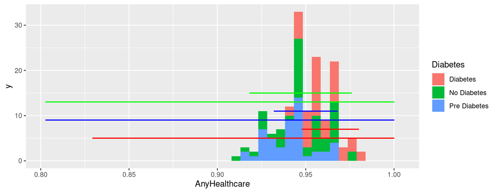

## BCa General Health

General Health m=50 n=250

|  | Mean | SD | CI_Low | CI_High |
| --- | --- | --- | --- | --- |
| No Diabetes | 2.374 | 1.018 | 2.265 | 2.455 |
| Pre Diabetes | 2.971 | 1.028 | 2.841 | 3.108 |
| Diabetes | 3.311 | 1.011 | 3.169 | 3.363 |

General Health m=5 n=10

[output not shown]

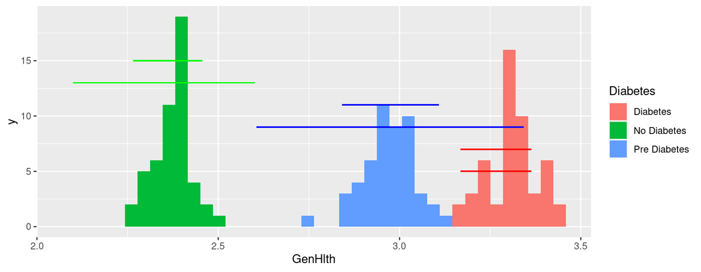

## BCa Income

Income m=50 n=250

[output not shown]

Income m=5 n=10

[output not shown]

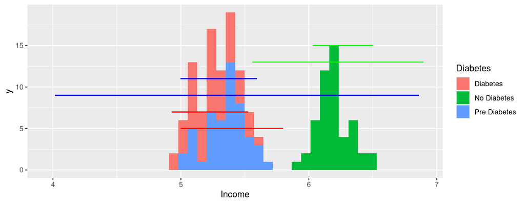

# Conclusion

Our ultimate goal was to be able to compare the different bootstrapping methods across a similar field. Bellow we can see the results of each method:

No-Pre Difference in Means

|  | Income | BMI | GenHlth | HighBP | Hlthcare | HighChol |
| --- | --- | --- | --- | --- | --- | --- |
| Percentile | TRUE | TRUE | TRUE | TRUE | FALSE | TRUE |
| Basic | TRUE | TRUE | TRUE | TRUE | FALSE | TRUE |
| Normal | TRUE | TRUE | TRUE | TRUE | FALSE | TRUE |
| Student-t | FALSE | TRUE | FALSE | FALSE | FALSE | TRUE |
| BCa | TRUE | TRUE | TRUE | TRUE | FALSE | TRUE |

Pre-Diab Difference in Means

[output not shown]

No-Diab Difference in Means

[output not shown]